# 01-annotating-bins

Jordan Winter

*This document goes over the steps to check the metagenome bins for completeness and contamination.*

# Find bins that are Sulfitobacter

Now that I’ve verified my 16S reads are *Sulfitobacter pontiacus*, I’ll check the bins. These bins are MAGs (metagenome assembled genomes), and I’ll find which are Sulfitobacter by using the CATBAT (https://github.com/dutilh/CAT) consensus results of what each contig is. Since I know what microbe each contig is, I’ll look for bins where most contigs are Roseobacteraceae, which is the family Sulfitobacter is in.

```r
# open file with all CATBAT results
classification <- read.csv("../data/CATBAT_all.txt", sep = "\t")

# run through each binning method
bin_path <- list.dirs("../data/Bins")
sulf_bins <- NULL
a <- 0

for (i in 2:7){

  pathname <- paste0(bin_path[i], "/")
  bins <- list.files(pathname)

  # get names of contigs in each bin
  for (binname in bins){
    print(binname)
    bin_pathname <- paste0(pathname, binname)
    contig_names <- read.csv(bin_pathname, header=F)
    all_contigs <- NULL

    # find contig names in the CATBAT results file
    for (i in 1:nrow(contig_names)){
      contigname <- contig_names[i,1]
      find_contig <- classification %>%
        filter(str_detect(X..contig, contigname))
      all_contigs <- rbind(all_contigs, find_contig)
    }

    # most ORFs (genes) have to be Sulfitobacter for me to look at the bin
    all_contigs$ORFs <- str_split_fixed(all_contigs$reason, "[ ]", 4)[,3]
    all_contigs$ORFs_true <- as.numeric(str_split_fixed(all_contigs$ORFs, "[/]", 4)[,1])
    consensus <- all_contigs %>%
      group_by(family) %>%
      summarize(support = sum(ORFs_true)) %>%
      filter(family != "no support") # don't include no support as a category
    index <- which(str_detect(consensus$family, "Roseobacteraceae"))
    consensus$family[index] <- "Roseobacteraceae"
    consensus <- consensus$family[which(consensus$support == max(consensus$support))]
    print(consensus)

    # if consensus is Roseobacter, add it to the bin list
    if (identical(consensus[str_detect(consensus, "Roseobacteraceae")], character(0)) == F){
      a <- a + 1
      sulf_bins$bin[a] <- binname
      sulf_bins$sample[a] <- basename(pathname)
    }
  }
}

sulf_bins <- as.data.frame(sulf_bins)
write.csv(sulf_bins, "../output/all_sulf_bins.csv")
```

```r
sulf_bins <- read.csv("../output/all_sulf_bins.csv")
head(sulf_bins$bin)
```

```
## [1] "24_sample_bam_bin.11"  "24_sample_bam_bin.118" "24_sample_bam_bin.134"
## [4] "24_sample_bam_bin.156" "24_sample_bam_bin.164" "24_sample_bam_bin.226"
```

# BUSCO

Once I have the bins I want, I can get some summary statistics. I used BUSCO (https://busco.ezlab.org) to get completeness, contamination, etc of bins. This is run on my own computer in a dedicated Conda environment, hence the Google Drive files.

The first step is to get fasta files of each bin, so putting all the contig fasta files into one file.

```r
# Get fasta files for each bin
sulf_bins <- read.csv("../output/all_sulf_bins.csv")
all <- readDNAStringSet("~/Library/CloudStorage/GoogleDrive-jwinter2@uw.edu/Shared drives/Rocap Lab/Project_ODZ_Marinimicrobia_Jordan/Assembly/1058_P1_2018_585_0.2um_assembly_plus.fa")
path <- "../data/Bins/"

for (i in 1:nrow(sulf_bins)){
  bin <- sulf_bins$bin[i]
  bintype <- sulf_bins$sample[i]
  bin_nms <- read.csv(paste0(path, bintype, "/", bin), header = F)

  # find all instances of each contig in the giant fasta file
  small_fa <- str_detect(all@ranges@NAMES, paste(bin_nms$V1, collapse = "|"))
  index <- which(small_fa == T)
  small_fa <- all[index]

  # export as a fasta file
  writeXStringSet(small_fa, paste0("../data/Bin_fa_sulf/", bin), format = "fasta")
}
```

Check output fasta files.

```r
fa <- readDNAStringSet("../data/Bin_fa_sulf/47_sample_bam_bin.41")
fa
```

```
## DNAStringSet object of length 4:
##       width seq                                             names
## [1]  287577 TTCCTGATCGCCGCGCGGCTTG...ATCGCTGTTGCCGCCGATCCTG MG1058_s0.ctg000001c
## [2] 2471245 ATCTCGGCGGGCAACCTCGACG...GGCCAGCGTTTCAAGCTGGCAA MG1058_s11.ctg000...
## [3]  479493 GTCGCACGCACGGTCAGACCGC...GCCAAGCTGCTGGCCGACCGCC MG1058_s285.ctg00...
## [4]  176822 GGGCGTCGCTGGCTGTGCGCCA...GCAGCGCAACAGGCGGGTCATG MG1058_s526.ctg00...
```

```bash
conda activate busco
busco -i github/jordan-marinimicrobia/data/Bin_fa_sulf -m geno -o github/jordan-marinimicrobia/output/busco_outputs_sulf -c 8 --auto-lineage-prok
```

Check BUSCO summary and combine it with the bins summary.

```r
busco <- read.delim("../output/busco_outputs_sulf/batch_summary.txt")
head(busco)
```

```
##               Input_file               Dataset Complete Single Duplicated
## 1        assembly_bin.67 rhodobacterales_odb10     98.9   98.9          0
## 2          tx_bam_bin.12 rhodobacterales_odb10     98.8   98.8          0
## 3   47_sample_bam_bin.41 rhodobacterales_odb10     98.9   98.9          0
## 4       assembly_bin.125 rhodobacterales_odb10     99.6   99.6          0
## 5 short_reads_bam_bin.38 rhodobacterales_odb10     99.6   99.6          0
## 6   assembly_plus_bin.27 rhodobacterales_odb10     98.9   98.9          0
##   Fragmented Missing n_markers                         Scores_archaea_odb10
## 1        0.4     0.7       833 C:17.0%[S:17.0%,D:0.0%],F:3.1%,M:79.9%,n:194
## 2        0.4     0.8       833 C:17.0%[S:17.0%,D:0.0%],F:3.1%,M:79.9%,n:194
## 3        0.4     0.7       833 C:17.0%[S:17.0%,D:0.0%],F:3.1%,M:79.9%,n:194
## 4        0.0     0.4       833 C:17.0%[S:17.0%,D:0.0%],F:3.1%,M:79.9%,n:194
## 5        0.0     0.4       833 C:17.0%[S:17.0%,D:0.0%],F:3.1%,M:79.9%,n:194
## 6        0.4     0.7       833 C:17.0%[S:17.0%,D:0.0%],F:3.1%,M:79.9%,n:194
##                         Scores_bacteria_odb10 Scores_eukaryota_odb10
## 1 C:97.6%[S:97.6%,D:0.0%],F:2.4%,M:0.0%,n:124                Not run
## 2 C:97.6%[S:97.6%,D:0.0%],F:2.4%,M:0.0%,n:124                Not run
## 3 C:97.6%[S:97.6%,D:0.0%],F:2.4%,M:0.0%,n:124                Not run
## 4 C:99.2%[S:99.2%,D:0.0%],F:0.8%,M:0.0%,n:124                Not run
## 5 C:99.2%[S:99.2%,D:0.0%],F:0.8%,M:0.0%,n:124                Not run
## 6 C:97.6%[S:97.6%,D:0.0%],F:2.4%,M:0.0%,n:124                Not run
##   Scaffold.N50 Contigs.N50 Percent.gaps Number.of.scaffolds
## 1      2471245     2471245       0.000%                   4
## 2      2471245     2471245       0.000%                   2
## 3      2471245     2471245       0.000%                   4
## 4      3034959     3034959       0.000%                   3
## 5      3034959     3034959       0.000%                   3
## 6      2471245     2471245       0.000%                   4
```

```r
busco <- read.delim("../output/busco_outputs_sulf/batch_summary.txt")
colnames(busco)[1] <- "bin"
sulf_bins <- merge(sulf_bins, busco)
write.csv(sulf_bins, "../output/all_sulf_bins.csv", row.names = F)
```

# Add sequence length to bin summary

Get sequence length of all the bins and add it to bin summary table.

```r
bin_path <- list.files("../data/Bin_fa_sulf") # annotated fasta files for each bin
lengths <- NULL

# get length of fasta files
for (i in 1:length(bin_path)){

  bin <- bin_path[i]
  bin_fullname <- paste0("../data/Bin_fa_sulf/", bin)

  lengths$bin[i] <- bin
  fa <- readDNAStringSet(bin_fullname, format = "fasta")
  lengths$sum_len[i] <- sum(nchar(fa))

}

lengths <- as.data.frame(lengths)
sulf_bins <- merge(sulf_bins, lengths)
write.csv(sulf_bins, "../output/all_sulf_bins.csv", row.names = F)
```

Look at bins summary table.

```r
sulf_bins <- read.csv("../output/all_sulf_bins.csv")
kable(head(sulf_bins, 5)) %>% scroll_box(width="100%", height = "200px")
```

| bin | X | sample | Dataset | Complete | Single | Duplicated | Fragmented | Missing | n_markers | Scaffold.N50 | Contigs.N50 | Percent.gaps | Number.of.scaffolds | sum_len |
| --- | --- | --- | --- | --- | --- | --- | --- | --- | --- | --- | --- | --- | --- | --- |
| 24_sample_bam_bin.11 | 1 | 24_sample_bam_bins | bacteria_odb10 | 12.1 | 11.3 | 0.8 | 2.4 | 85.5 | 124 | 16860 | 16860 | 0.000% | 34 | 576810 |
| 24_sample_bam_bin.118 | 2 | 24_sample_bam_bins | bacteria_odb10 | 0.8 | 0.8 | 0.0 | 1.6 | 97.6 | 124 | 11016 | 11016 | 0.000% | 82 | 913463 |
| 24_sample_bam_bin.134 | 3 | 24_sample_bam_bins | bacteria_odb10 | 14.5 | 13.7 | 0.8 | 4.8 | 80.7 | 124 | 12734 | 12734 | 0.000% | 48 | 605550 |
| 24_sample_bam_bin.156 | 4 | 24_sample_bam_bins | bacteria_odb10 | 32.3 | 24.2 | 8.1 | 4.8 | 62.9 | 124 | 11009 | 11009 | 0.000% | 210 | 2297295 |
| 24_sample_bam_bin.164 | 5 | 24_sample_bam_bins | bacteria_odb10 | 8.9 | 8.1 | 0.8 | 1.6 | 89.5 | 124 | 10322 | 10322 | 0.000% | 25 | 265173 |

# Create alluvial plot

Create alluvial plot to check what contigs/reads went where in each binning method using 47_sample_bam_bin.81, which is Sulfitobacter. As can be seen in the plot, most binning methods had the same contigs in them. This indicates it’s likely these contigs do belong in the same bin.

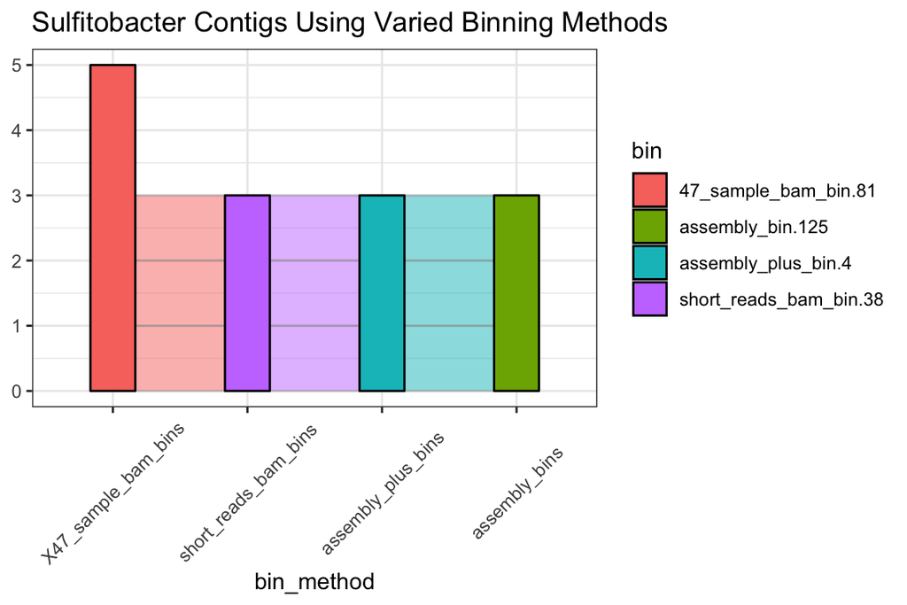

```r
# open file
alluvial <- read.csv("../output/for_alluvial_plot.csv")

# choose starting bin
alluvial <- subset(alluvial, X47_sample_bam_bins == "47_sample_bam_bin.81")

# manipulate data to get it in a format for the alluvial plot
alluvial <- pivot_longer(alluvial, cols=c(colnames(alluvial)[2:7]), names_to="bin_method", values_to="bin")
alluvial <- subset(alluvial, is.na(bin) == F)
alluvial$bin_method <- factor(alluvial$bin_method, levels = c("X24_sample_bam_bins","X47_sample_bam_bins", "short_reads_bam_bins",
  "transcriptomes_bam_bins","assembly_plus_bins","assembly_bins"))

ggplot(alluvial,
       aes(x = bin_method, stratum = bin, alluvium = contig_name,
           fill = bin, label = bin)) +
  geom_flow(stat = "alluvium", lode.guidance = "frontback",
            color = "darkgray") +
  geom_stratum() +
  theme_bw() +
  theme(axis.text.x = element_text(angle = 45, vjust=0.5)) +
  ggtitle("Sulfitobacter Contigs Using Varied Binning Methods")
```